# Tema 02 - Visualización de datos

La Gramática de Gráficos para Análisis Económico

Pedro Albarrán

Dpto. de Fundamentos del Análisis Económico. Universidad de Alicante

## ¿Por qué visualizar datos?

- **Resumir información** que no se vería en los datos en bruto (hoja de cálculo)
- **Identificar patrones** y relaciones entre variables
- **Comunicar hallazgos** de forma efectiva a diferentes audiencias
- La visualización es esencial en:
  - *Empresas y consultoras*: presentaciones ejecutivas con las conclusiones que salen de los datos
  - *Bancos centrales y gobiernos*: paneles de indicadores macroeconómicos
  - *Medios*: The Economist, Financial Times
  - *Investigación económica*
- En un buen gráfico, la audiencia encuentra obvias las ideas a transmitir, sin *abrumar* con muchos hallazgos

## `ggplot2` y la Gramática de Gráficos

- Componentes básicos:
  - *Datos*
  - *Estéticas (aes)*: asocia variables a propiedades visuales (posición, longitud, área, color)
  - *Geometrías (geom)*: objetos para representar datos (líneas, círculos, barras)
  - *Escalas*, *Sistemas de coordenadas*, *Facetas* (subgráficos), *Contexto* (títulos, leyendas), etc.
- Construir gráficos como frases gramaticales
  - sujeto + verbo + objeto = oración
  - datos + geometría + estética = gráfico de `ggplot2`

**“Por encima de todo, mostrar los datos”**

## Los datos del tema

- Trabajaremos con una **cadena de gimnasios** y su entorno. Son tres conjuntos de datos, y cada uno responde a una pregunta distinta

```r
library(ggplot2)
load("data/datosVisualizacion.RData")
```

- **¿Quién es nuestra clientela y en qué se diferencia?** `clientes`, una ficha por persona: lo que ingresa, lo que gasta, su edad, por qué canal compra y en qué segmento está
- **¿Cómo va el negocio y de qué depende?** `ventas`: cuánto se vendió y cuánto se invirtió en marketing, en cada región, producto y trimestre
- **¿En qué entorno operamos?** `macro`, un país por fila: renta, población, paro, inflación y deuda
- De cada conjunto salen **muchas preguntas**, y cada una pide su propio gráfico
- La descripción de cada variable está en su diccionario: `clientes_info`, `ventas_info`, `macro_info`
- Los ficheros se descargan de la página **Datos** del curso, y van en un subdirectorio `data` dentro de vuestra carpeta del tema

## Creando un “ggplot”

Un gráfico se construye en **tres pasos**. Cada pestaña añade uno:

- 1. Los datos
- 2. La estética
- 3. La geometría

`ggplot()` con los datos solos da un lienzo **vacío**: todavía no hemos dicho qué variable va a cada sitio.

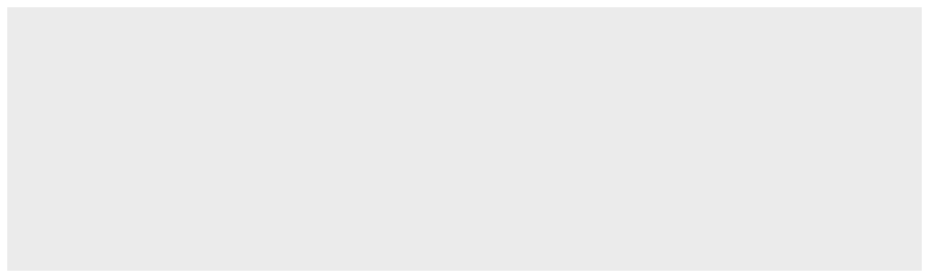

```r
ggplot(data = ventas)
```

La **estética** es la correspondencia entre una variable y una propiedad visual del gráfico. Se declara con `aes()`: aquí, qué variable va en cada eje. Ya hay ejes, pero aún no hay nada dibujado.

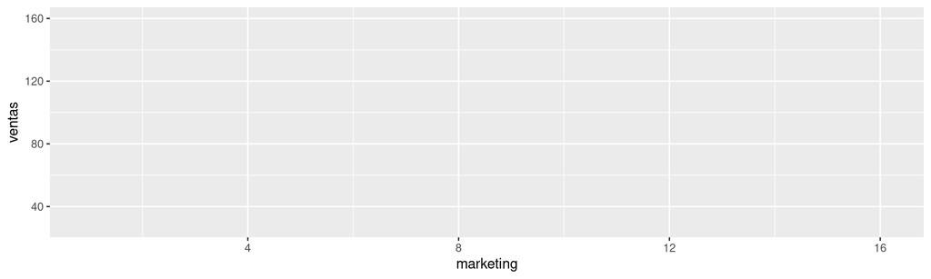

```r
ggplot(data = ventas, aes(x = marketing, y = ventas))
```

El **objeto geométrico** es la forma que toman los datos: puntos, barras, líneas… Se añade como una capa más, con `+`.

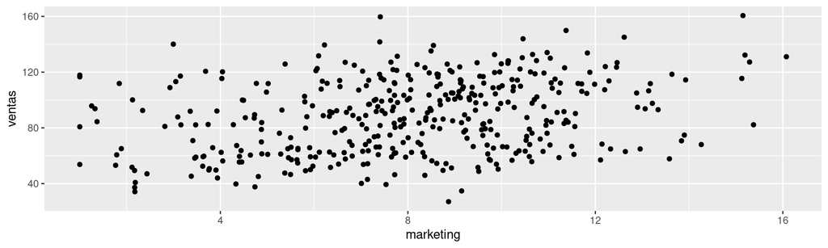

```r
ggplot(data = ventas, aes(x = marketing, y = ventas)) +
  geom_point()
```

- La **estética** y la **geometría** son las dos piezas que vemos a continuación

## ¿Dónde se pone la estética?

- Si `aes()` va en **`ggplot()`**, la estética vale para **todas las capas** que vengan detrás. Si va dentro de un **`geom_`**, vale **solo para esa capa**
- Con una sola capa, las dos formas dan **el mismo gráfico**:

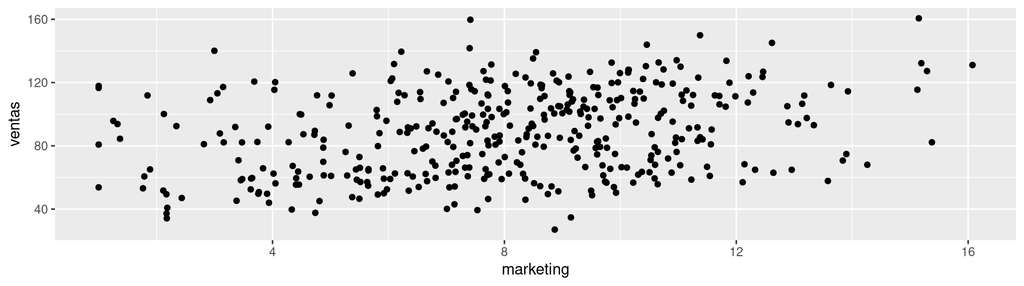

```r
ggplot(ventas,
       aes(marketing, ventas)) +
  geom_point()
```

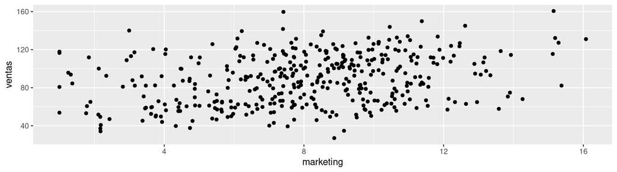

```r
ggplot(ventas) +
  geom_point(
    aes(marketing, ventas))
```

- La diferencia aparece **en cuanto hay más de una capa**: lo declarado en `ggplot()` lo heredan todas, y así no hay que repetirlo

## Objetos Geométricos

Cada `geom_*()` agrega un tipo diferente de capa:

| Tipo | Función | Uso Habitual |
| --- | --- | --- |
| **Puntos** | `geom_point()` | Dispersión |
| **Líneas** | `geom_line()` | Evolución temporal |
| **Barras** | `geom_bar()` | Frecuencias categóricas |
| **Histograma** | `geom_histogram()` | Distribución continua |
| **Cajas** | `geom_boxplot()` | Estadísticos descriptivos |
| **Suavizado** | `geom_smooth()` | Tendencias |
| **Texto** | `geom_text()` | Etiquetas |

Para lista completa: buscar funciones que comienzan con `geom_` en Ayuda

## Asociación Estética, con `aes()`

- Cada `aes()` es una asociación entre una **señal visual** y una **variable**:

  | **posición**: `x`, `y` | \| | **forma**: `shape` |
  | --- | --- | --- |
  | **color**: color exterior | \| | **relleno**: `fill` (color interior) |
  | **tamaño**: `size` | \| | **tipo de línea**: `linetype` |

- Algunas estéticas son solo adecuadas para variables cuantitativas o para cualitativas
- Cada `geom` acepta solo un subconjunto de estéticas (ver ayuda)
- **Regla de oro**: Si quieres que algo varíe con los datos, ponlo en `aes()`

```r
ggplot(ventas, aes(x = marketing, y = ventas)) +
  geom_point(aes(color = region))
```

## Asociación Estética vs. Opción Fija

**Dentro** de `aes()`: una **variable** se traduce en una señal visual, y aparece su leyenda

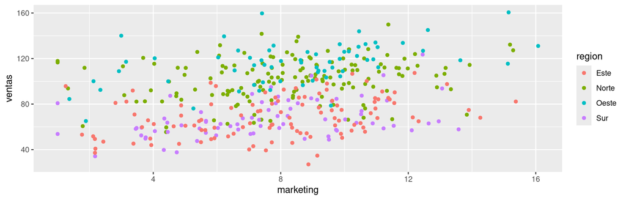

```r
ggplot(ventas,
       aes(marketing, ventas)) +
  geom_point(
    aes(color = region))
```

**Fuera** de `aes()`: un **valor fijo**, igual para todos los puntos, sin leyenda

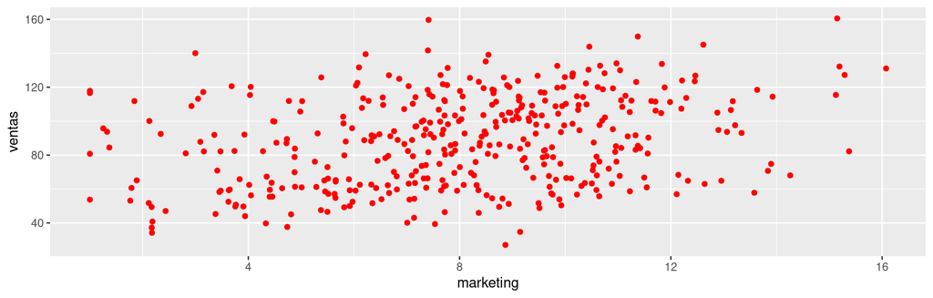

```r
ggplot(ventas,
       aes(marketing, ventas)) +
  geom_point(
    color = "red")
```

- **Principio**: cada señal visual debe representar **información**, no “embellecer”. Y no saturar: tres o cuatro variables a la vez no se leen

```r
ggplot(macro, aes(y = desempleo, x = pib)) +        # demasiado
  geom_point(aes(size = inflacion, color = deuda))
```

## PRÁCTICA en clase (1): ¿rojo o “rojo”?

Con el data frame `clientes` (300 fichas de la clientela de nuestra cadena de gimnasios):

1. Dibujad la relación entre `ingresos` y `gasto` con `geom_point()`
2. Pintad TODOS los puntos de rojo, de verdad (que no aparezca ninguna leyenda)
3. Ahora ejecutad esto y describid qué veis: ¿de qué color salen los puntos? ¿qué dice la leyenda? ¿por qué?

   `ggplot(clientes, aes(x = ingresos, y = gasto)) + geom_point(aes(color = "red"))`
4. Distinguid el `segmento` por color y el `canal` por forma. Y ahora añadid además `size = edad`. ¿Se lee el gráfico con tres variables encima? ¿Cuántas cosas a la vez puede leer quien lo mira?
5. Añadid `size = 4` dentro de `aes()` y luego fuera. Una de las dos no tiene sentido: ¿cuál y por qué? En una frase, ¿qué regla os sirve para decidirlo?

**Nota**

**Esta práctica es el apartado a) del ejercicio 1**: id haciéndola ahí, en vuestro `.qmd`.

## Gráficos como Objetos

- Un gráfico también es un objeto de R

```r
graf_base <- ggplot(macro, aes(y = desempleo, x = pib)) +
                geom_point()
```

- Se pueden agregar capas a este objeto:

```r
graf_base + geom_line()
graf_base + geom_point(aes(shape = norte))
graf_base + geom_point(aes(size = inflacion, color = deuda))
```

## Datos (y estéticas) específicas por capa

#### Ejemplo práctico:

- `geom_text()`: acepta estéticas de etiquetas (variables con texto):

```r
graf_base + geom_text(aes(label = pais), size = 3)

library(ggrepel)  # Evita solapamiento
graf_base + geom_text_repel(aes(label = pais), size = 3)
```

- Ahora con datos específicos por capa si solo queremos señalar algunos puntos

```r
graf_base +
  geom_text_repel(
    data = subset(macro,
                  pais %in% c("España","Francia","Alemania")),
    aes(label = pais), size = 3)
```

- Esta idea se puede **generalizar**: usar distintos datos o estéticas en cada capa según las necesidades del gráfico

**Nota**

**Ahora el ejercicio 1, apartado b)**: etiquetar a quienes más gastan, con su propia capa de datos.

## Gráficos que muestran datos transformados

- Un gráfico de dispersión dibuja **los datos tal cual**. Otros **calculan algo antes de dibujar**, y conviene saber qué
- Cajas
- Tendencia

`geom_boxplot()` no dibuja las observaciones: dibuja sus **cuartiles y su mediana**

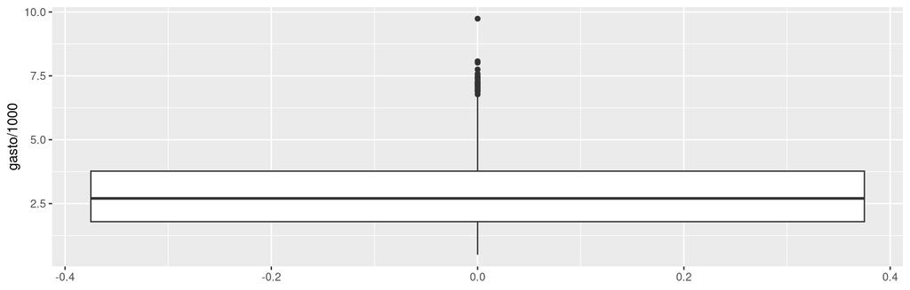

```r
ggplot(clientes,
       aes(y = gasto/1000)) +
  geom_boxplot()
```

[figure not shown]

`geom_smooth()` **estima una regresión** y dibuja la línea predicha, con su intervalo de confianza

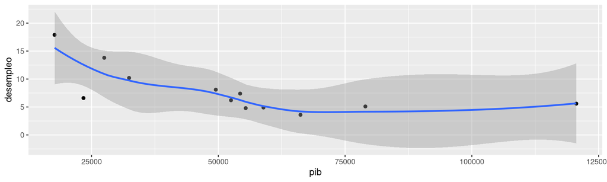

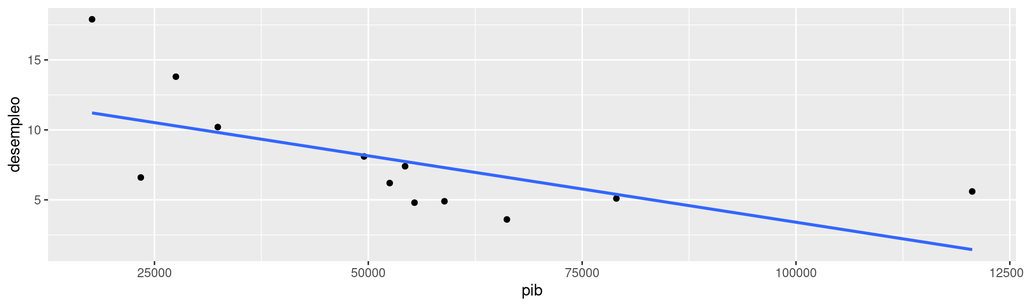

```r
graf_base + geom_smooth()
graf_base + geom_smooth(method = lm, se = FALSE)
```

## Gráficos que muestran datos transformados (cont.)

- `geom_bar()` y `geom_histogram()` convierten los datos en **frecuencias**
- Recuento
- Intervalos
- Densidad

`geom_bar()` **cuenta** los casos de cada categoría: no hay que calcular nada antes. En Excel habría que haber contado primero

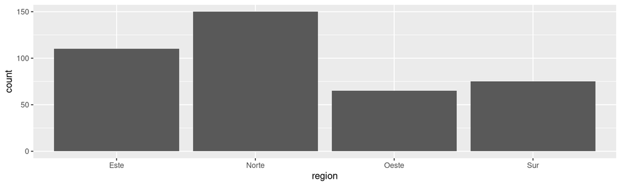

```r
ggplot(ventas, aes(x = region)) + geom_bar()
```

En una variable continua **no hay categorías naturales**: los intervalos los elegimos nosotros, y esa elección cambia lo que se ve

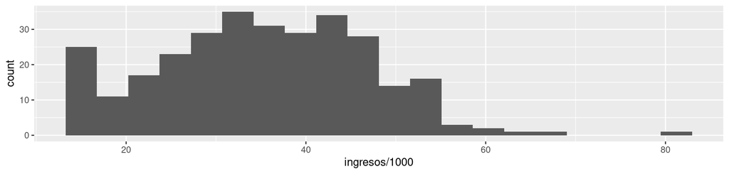

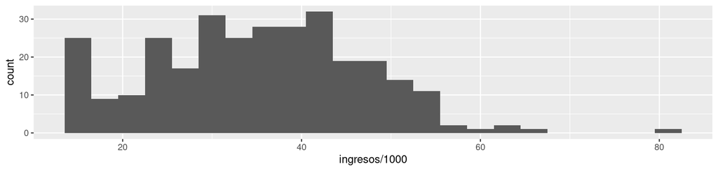

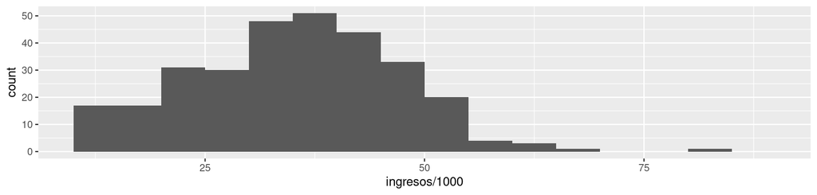

```r
graf <- ggplot(clientes, aes(x = ingresos/1000))
graf + geom_histogram(bins = 20)
graf + geom_histogram(binwidth = 3)
graf + geom_histogram(breaks = seq(10,90,5))
```

La misma información sin elegir intervalos, en frecuencia relativa

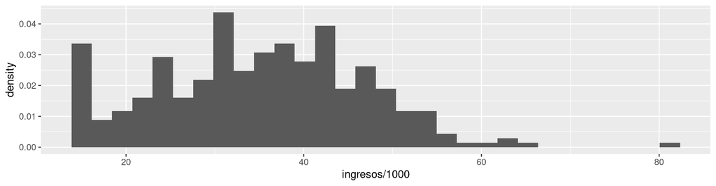

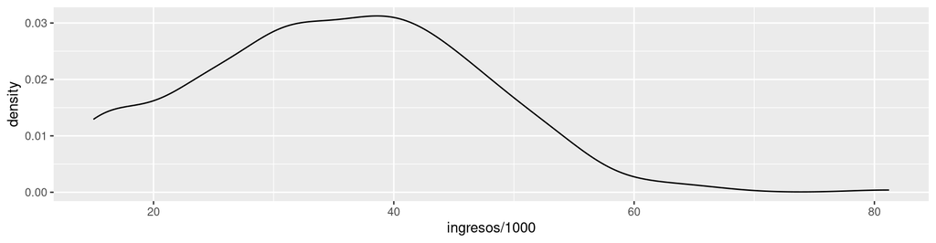

```r
graf + geom_histogram(aes(y = after_stat(density)))
graf + geom_density()
```

## PRÁCTICA en clase (2): el gráfico calcula por ti

Venís de Excel, donde para hacer un gráfico de barras hay que contar antes. Aquí no. Con `clientes`:

1. Número de clientes de cada `segmento`, con `geom_bar()`. ¿Dónde está la tabla de frecuencias que habéis usado?
2. Lo mismo, pero con la PROPORCIÓN que representa cada segmento, sin calcular nada aparte: el `geom` ya ha contado, y `after_stat()` deja usar lo que ha calculado

```r
ggplot(clientes, aes(x = segmento, y = after_stat(prop), group = 1)) +
  geom_bar()
```

3. En una frase: ¿qué significa que un `geom` “tiene una estadística por defecto”?

**Nota**

**Esta práctica es el apartado c) del ejercicio 1.**

## PRÁCTICA en clase (3): distribuciones

1. Distribución de los `ingresos` con `geom_histogram()`, probando `bins = 10`, `bins = 40` y `binwidth = 3`. ¿Cuál de las tres le enseñaríais a dirección y por qué?
2. Con una de las tres se ve un grupo de clientes de ingresos muy bajos y con las otras no. ¿Con cuál, y qué os dice eso sobre elegir los intervalos?
3. Añadid un `geom_boxplot()` del `gasto` por `segmento`

**Nota**

**Esta práctica es el apartado d) del ejercicio 1.**

## Escalas: Control de Asociación Estética

- `aes()` establece **qué** variable asignar, la escala **cómo** representarla
- Funciones de escala: `scale_<estética>_<tipo>`. Ejemplos,

| **Escala** | **Tipos** | **Ejemplos** |
| --- | --- | --- |
| scale_color_ | identity | scale_fill_continuous |
| scale_fill_ | manual | scale_color_discrete |
| scale_size_ | continuous | scale_color_manual |
|  | discrete | scale_size_discrete |
| scale_shape_ | discrete | scale_shape_discrete |
| scale_linetype_ | manual | scale_shape_manual |
|  | identity | scale_linetype_discrete |
| scale_x_ | continuous | scale_x_continuous |
| scale_y_ | discrete | scale_y_discrete |
|  | reverse | scale_y_reverse |
|  | log10 | scale_x_log10 |
|  | date | scale_x_date |
|  | datetime | scale_y_datetime |

## Escalas (cont.)

- Algunos argumentos son habituales en casi todas las escalas (`name`, `breaks`, `labels`)
- Otros argumentos son específicos según el tipo de variables (continua, discreta) o la escala concreta

```r
ggplot(macro, aes(y = pais, x = pib)) +
  geom_point(aes(color = desempleo))  +
  scale_color_continuous(breaks = c(5, 10, 15),
                         labels = c("Bajo", "Medio", "Alto"),
                         low = "green", high = "red")

ggplot(macro, aes(y = desempleo, x = pib/1000)) +
  geom_point(aes(color = norte, size = deuda, shape = norte)) +
  scale_y_continuous(breaks = seq(0, 20, 5), limits = c(-5, 25)) +
  scale_shape_discrete(labels = c("Norte", "Sur"),
                       name = "Zona de Europa")
```

- Nota: este ejemplo tiene elementos redundantes a efectos ilustrativos

## Escala Logarítmica

```r
ggplot(macro, aes(y = desempleo, x = poblacion)) +
  scale_x_log10(breaks = seq(0,100,20)) + geom_point()
```

- Mejor que `x = log(pib)` porque los ejes se muestran en unidades originales
- Usar logs **cambia la interpretación** de diferencias absolutas a porcentuales
  - Más relevante +10% o +500 clientes (mucho en pyme, nada en Inditex)
  - **NO** para “evitar” valores extremos o distribución asimétrica

## PRÁCTICA en clase (4): la misma pregunta en dos escalas

Una consultora de inversión compara el perfil de ingresos de cinco grandes corporaciones y cinco startups. Los datos están en la página **Datos** del curso:

```r
load("data/empresas.RData")
empresas_info      # qué es cada variable
```

1. Diagrama de cajas de `ingresos_millones` por `tipo`, en escala normal
2. El mismo gráfico con `scale_y_log10()`
3. Comparando los dos: ¿qué diferencias hay en la posición central y en la variabilidad dentro de cada grupo? ¿Cuál de los dos gráficos es más informativo, y por qué?
4. Si esa variabilidad mide el riesgo de una inversión, ¿dónde es más arriesgado invertir?

**Nota**

**Esta práctica es el ejercicio 2**, el de corporaciones y startups.

## Facetas (sub-gráficos)

- Los sub-gráficos por variables *categóricas* son una alternativa a `aes()` para añadir variables
- Facilitan comparaciones, evitando la saturación visual (ej., demasiadas líneas en un solo gráfico)

```r
graf_tiempo <- ggplot(ventas_tiempo, aes(x = fecha, y = ventas))
graf_tiempo + geom_line(aes(color = region))
```

- `facet_wrap()`: facetas por una variable (usando “fórmula” `~`)

```r
graf_tiempo + geom_line() + facet_wrap(~region, ncol = 2)
```

- `facet_grid()`: facetas en dos dimensiones

```r
g3 <- ggplot(data = clientes) + geom_histogram(aes(x = gasto))
g3 + facet_grid(segmento ~ canal)  # Filas y columnas
g3 + facet_grid(segmento ~ .)      # Solo por filas
g3 + facet_grid(. ~ canal)         # Solo por columnas
```

## Contexto con `labs()`

- Una **buena práctica** de legibilidad es dar título al gráfico, nombrar los ejes, incluir leyendas
  - Descripciones claras de variables y sus unidades

```r
ggplot(macro, aes(y = desempleo, x = pib/1000)) +
  geom_point(aes(color = norte, size = deuda)) +
  geom_smooth(method = "lm", se = FALSE) +
  labs(
    title = "Relación entre PIB per cápita y tasa de desempleo",
    subtitle = "Países de la Unión Europea (2023)",
    caption = "Fuente: Eurostat",
    x = "PIB per cápita (miles de €)",
    y = "Tasa de desempleo (%)",
    color = "Norte",
    size = "Deuda pública (% PIB)") +
  scale_y_continuous(breaks = seq(0, 20, 5))
```

## Otros Elementos de Contexto

- **`annotate()`**: añade objetos geométricos NO asociados a variables:

```r
ggplot(macro, aes(y = desempleo, x = pib/1000)) +
  geom_point(aes(color = norte)) +
  geom_smooth(method = "lm", se = FALSE) +
  annotate("text", x = 60, y = 11,
           label = "La doble división Norte-Sur") +
  annotate("text", x = 85, y = 6, label = "R ^ 2 == 0.45",
           parse = TRUE)
```

- **Líneas de Referencia**

```r
ggplot(clientes, aes(x = canal, y = gasto/1000)) +
  geom_boxplot() +
  geom_hline(yintercept = 3.0, linetype = "dashed",
             color = "red") +
  annotate("text", x = 3, y = 3.3,
           label = "Objetivo mínimo", color = "red")
```

## Personalizar el aspecto general

- Se pueden cambiar manualmente **colores** (p.e., `scale_fill_manual()`) o la forma (ej., `scale_shape_manual()`)
- PERO es preferible usar *paletas predefinidas* con criterios de diseño y visualización de *información*:

```r
graf <- ggplot(ventas, aes(x = region, y = ventas, fill = region)) +
          geom_boxplot()
library(RColorBrewer)
display.brewer.all()
graf + scale_fill_brewer(palette = "Set2")
```

- Se puede añadir una capa de **tema** (estilo general de todos los componentes)

```r
graf + theme_gray()
```

```r
graf + theme_minimal()
```

- También existen **temas profesionales** predefinidos en bibliotecas

```r
library(ggthemes)
graf + theme_economist() + scale_fill_economist()
```

**Nota**

**Ahora el ejercicio 1, apartado e)**: tendencia, facetas, línea de referencia, `labs()` y temas.

## Cierre: buenas prácticas

- **Buenas prácticas**: visualizar no es decorar datos, es comunicar *insights*
  - Una idea por gráfico
  - *Claridad* sobre ornamentación: cada elemento visual debe tener propósito
  - Títulos y leyendas *descriptivos* e informativos
  - Evitar demasiados colores o patrones y la sobrecarga de información

## Comentarios Finales

- **Guardar gráficos**: en el panel *Plots*, con el botón **Save Plot** (en RStudio era *Export*), o con el comando

```r
ggsave("analisis-ventas.pdf")
ggsave("dashboard-macro.png", width = 12, height = 8, dpi = 300)
```

- **Recursos de Ayuda**
  - *Help > Cheatsheets > Data Visualization with ggplot2*
  - [Chuletas de R, ggplot2 y más](https://posit.co/resources/cheatsheets/)
  - [R Graph Gallery](https://r-graph-gallery.com/)
  - [ggplot2 book](https://ggplot2-book.org/)
- **Otras bibliotecas de gráficos** en R
  - `plotly`: gráficos interactivos para dashboards
  - `gganimate`: animaciones para evolución temporal